# Return Home

[View Code on Github](https://github.com/JohnKimaiyo/Data-Analysis-Projects/blob/main/Python/Youtube%20Data%20API/Top%20%20Crypto%20Channels%20to%20Watch%20in%202024.ipynb)

# Top Crypto Channels to Watch in 2024

## 1 Coin Bureau

Coin Bureau, led by Guy, entered the YouTube universe in 2019 and has been a leading source of news relating to the cryptoverse. It is one of the best cryptocurrency YouTube channels that provides its viewers with relevant information about crypto, price predictions, fundamentals about cryptocurrency analysis, and upcoming coins

## 3 Altcoin Daily

Austin and Aaron Arnold are the masterminds behind Altcoin Daily, which has over 1.29 million YouTube subscribers. They launched their one of the best crypto YouTube channels in 2018 after they began to invest in the early digital coin market.

## 4 Brian Jung

Brian Jung has over 1.25 million YouTube subscribers and has been posting videos since the end of 2018. He is a serial entrepreneur from Washington, D.C., with great experience in investments. He uploads the best educational videos about crypto news, credit and debit cards, and how to assess personal finance.

## 5 Benjamin Cowen

Benjamin Cowen, with YouTube 784K subscribers, has an advanced perspective on the best technical analysis of the cryptocurrency. He has a doctorate in engineering and is a source of knowledge for anything related to computational mathematics and programming.

```python
# lets import libraries
from googleapiclient.discovery import build
import pandas as pd
import seaborn as sn
```

## 1 Coin Bureau

```python
# Function to get channel statistics
api_key = 'AIzaSyB24Kop04L1GlTgRCm1XtQ4KB2a4gaBOwA'
Coin_Bureau_channel_id = ['UCqK_GSMbpiV8spgD3ZGloSw' # Coin Bureau

              ]
youtube = build('youtube','v3',developerKey = api_key)

from googleapiclient.errors import HttpError

def get_channel_stats(youtube, Coin_Bureau_channel_id):
    all_data = []
    try:
        request = youtube.channels().list(
            part='snippet,contentDetails,statistics',
            id=','.join(Coin_Bureau_channel_id)
        )
        response = request.execute()

        for item in response.get('items', []):
            snippet = item.get('snippet', {})
            statistics = item.get('statistics', {})

            data = {
                'Channel_name': snippet.get('title', ''),
                'Subscribers': statistics.get('subscriberCount', ''),
                'Views': statistics.get('viewCount', ''),
                'Total_videos': statistics.get('videoCount', '')
            }

            all_data.append(data)

    except HttpError as e:
        print(f"HTTP error occurred: {e}")
        print(f"Request URL: {e.resp.request.url}")
        print(f"Request body: {e.resp.request.body}")

    return all_data
```

```python
get_channel_stats(youtube,Coin_Bureau_channel_id)
```

```
[{'Channel_name': 'Coin Bureau',
  'Subscribers': '2400000',
  'Views': '230280246',
  'Total_videos': '1128'}]
```

```python
channel_statistics = get_channel_stats(youtube, Coin_Bureau_channel_id)
```

```python
Coin_Bureau_channel_data =pd.DataFrame(channel_statistics)
```

```python
Coin_Bureau_channel_data
```

|  | Channel_name | Subscribers | Views | Total_videos |
| --- | --- | --- | --- | --- |
| 0 | Coin Bureau | 2400000 | 230280246 | 1128 |

```python
# Function to get channel statistics
api_key = 'AIzaSyB24Kop04L1GlTgRCm1XtQ4KB2a4gaBOwA'
BitBoy_Crypto_channel_id = ['UCuV9EB4I9L-xmRoaXd8tmuA' # BitBoy Crypto

              ]
youtube = build('youtube','v3',developerKey = api_key)

from googleapiclient.errors import HttpError

def get_channel_stats(youtube, BitBoy_Crypto_channel_id):
    all_data = []
    try:
        request = youtube.channels().list(
            part='snippet,contentDetails,statistics',
            id=','.join(BitBoy_Crypto_channel_id)
        )
        response = request.execute()

        for item in response.get('items', []):
            snippet = item.get('snippet', {})
            statistics = item.get('statistics', {})

            data = {
                'Channel_name': snippet.get('title', ''),
                'Subscribers': statistics.get('subscriberCount', ''),
                'Views': statistics.get('viewCount', ''),
                'Total_videos': statistics.get('videoCount', '')
            }

            all_data.append(data)

    except HttpError as e:
        print(f"HTTP error occurred: {e}")
        print(f"Request URL: {e.resp.request.url}")
        print(f"Request body: {e.resp.request.body}")

    return all_data
```

```python
get_channel_stats(youtube,BitBoy_Crypto_channel_id)
```

```
[{'Channel_name': 'Ben Armstrong',
  'Subscribers': '92400',
  'Views': '7724692',
  'Total_videos': '396'}]
```

```python
channel_statistics = get_channel_stats(youtube, BitBoy_Crypto_channel_id)
```

```python
BitBoy_Crypto_channel_data =pd.DataFrame(channel_statistics)
```

```python
BitBoy_Crypto_channel_data
```

|  | Channel_name | Subscribers | Views | Total_videos |
| --- | --- | --- | --- | --- |
| 0 | Ben Armstrong | 92400 | 7724692 | 396 |

## 3 Altcoin Daily

```python
# Function to get channel statistics
api_key = 'AIzaSyB24Kop04L1GlTgRCm1XtQ4KB2a4gaBOwA'
Altcoin_Daily_channel_id = ['UCbLhGKVY-bJPcawebgtNfbw' # Altcoin Daily

              ]
youtube = build('youtube','v3',developerKey = api_key)

from googleapiclient.errors import HttpError

def get_channel_stats(youtube, Altcoin_Daily_channel_id):
    all_data = []
    try:
        request = youtube.channels().list(
            part='snippet,contentDetails,statistics',
            id=','.join(Altcoin_Daily_channel_id)
        )
        response = request.execute()

        for item in response.get('items', []):
            snippet = item.get('snippet', {})
            statistics = item.get('statistics', {})

            data = {
                'Channel_name': snippet.get('title', ''),
                'Subscribers': statistics.get('subscriberCount', ''),
                'Views': statistics.get('viewCount', ''),
                'Total_videos': statistics.get('videoCount', '')
            }

            all_data.append(data)

    except HttpError as e:
        print(f"HTTP error occurred: {e}")
        print(f"Request URL: {e.resp.request.url}")
        print(f"Request body: {e.resp.request.body}")

    return all_data
```

```python
get_channel_stats(youtube,Altcoin_Daily_channel_id)
```

```
[{'Channel_name': 'Altcoin Daily',
  'Subscribers': '1390000',
  'Views': '206365467',
  'Total_videos': '2566'}]
```

```python
channel_statistics = get_channel_stats(youtube, Altcoin_Daily_channel_id)
```

```python
Altcoin_Daily_channel_data =pd.DataFrame(channel_statistics)
```

```python
Altcoin_Daily_channel_data
```

|  | Channel_name | Subscribers | Views | Total_videos |
| --- | --- | --- | --- | --- |
| 0 | Altcoin Daily | 1390000 | 206365467 | 2566 |

## 4 Brian Jung

```python
# Function to get channel statistics
api_key = 'AIzaSyB24Kop04L1GlTgRCm1XtQ4KB2a4gaBOwA'
Brian_Jung_channel_id = ['UCQglaVhGOBI0BR5S6IJnQPg' # Brian Jung

              ]
youtube = build('youtube','v3',developerKey = api_key)

from googleapiclient.errors import HttpError

def get_channel_stats(youtube, Brian_Jung_channel_id):
    all_data = []
    try:
        request = youtube.channels().list(
            part='snippet,contentDetails,statistics',
            id=','.join(Brian_Jung_channel_id)
        )
        response = request.execute()

        for item in response.get('items', []):
            snippet = item.get('snippet', {})
            statistics = item.get('statistics', {})

            data = {
                'Channel_name': snippet.get('title', ''),
                'Subscribers': statistics.get('subscriberCount', ''),
                'Views': statistics.get('viewCount', ''),
                'Total_videos': statistics.get('videoCount', '')
            }

            all_data.append(data)

    except HttpError as e:
        print(f"HTTP error occurred: {e}")
        print(f"Request URL: {e.resp.request.url}")
        print(f"Request body: {e.resp.request.body}")

    return all_data
```

```python
get_channel_stats(youtube,Brian_Jung_channel_id)
```

```
[{'Channel_name': 'Brian Jung',
  'Subscribers': '1540000',
  'Views': '77130591',
  'Total_videos': '542'}]
```

```python
channel_statistics = get_channel_stats(youtube, Brian_Jung_channel_id)
```

```python
Brian_Jung_channel_data =pd.DataFrame(channel_statistics)
```

```python
Brian_Jung_channel_data
```

|  | Channel_name | Subscribers | Views | Total_videos |
| --- | --- | --- | --- | --- |
| 0 | Brian Jung | 1540000 | 77130591 | 542 |

## 5 Benjamin Cowen

```python
# Function to get channel statistics
api_key = 'AIzaSyB24Kop04L1GlTgRCm1XtQ4KB2a4gaBOwA'
Benjamin_Cowen_channel_id = ['UCRvqjQPSeaWn-uEx-w0XOIg' # Benjamin Cowen

              ]
youtube = build('youtube','v3',developerKey = api_key)

from googleapiclient.errors import HttpError

def get_channel_stats(youtube, Benjamin_Cowen_channel_id):
    all_data = []
    try:
        request = youtube.channels().list(
            part='snippet,contentDetails,statistics',
            id=','.join(Benjamin_Cowen_channel_id)
        )
        response = request.execute()

        for item in response.get('items', []):
            snippet = item.get('snippet', {})
            statistics = item.get('statistics', {})

            data = {
                'Channel_name': snippet.get('title', ''),
                'Subscribers': statistics.get('subscriberCount', ''),
                'Views': statistics.get('viewCount', ''),
                'Total_videos': statistics.get('videoCount', '')
            }

            all_data.append(data)

    except HttpError as e:
        print(f"HTTP error occurred: {e}")
        print(f"Request URL: {e.resp.request.url}")
        print(f"Request body: {e.resp.request.body}")

    return all_data
```

```python
get_channel_stats(youtube,Benjamin_Cowen_channel_id)
```

```
[{'Channel_name': 'Benjamin Cowen',
  'Subscribers': '789000',
  'Views': '109022574',
  'Total_videos': '2154'}]
```

```python
channel_statistics = get_channel_stats(youtube, Benjamin_Cowen_channel_id)
```

```python
Benjamin_Cowen_channel_data =pd.DataFrame(channel_statistics)
```

```python
Benjamin_Cowen_channel_data
```

|  | Channel_name | Subscribers | Views | Total_videos |
| --- | --- | --- | --- | --- |
| 0 | Benjamin Cowen | 789000 | 109022574 | 2154 |

```python
# Lets combine the data frames
# Combine DataFrames using concat
combined_crypto_channels_df = pd.concat([Coin_Bureau_channel_data ,
                                       BitBoy_Crypto_channel_data ,
                                     Altcoin_Daily_channel_data ,
                                       Brian_Jung_channel_data ,
                                      Benjamin_Cowen_channel_data,
                                                                                ], ignore_index=True)

# Display the result
print(combined_crypto_channels_df)
```

```
     Channel_name Subscribers      Views Total_videos
0     Coin Bureau     2400000  230280246         1128
1   Ben Armstrong       92400    7724692          396
2   Altcoin Daily     1390000  206365467         2566
3      Brian Jung     1540000   77130591          542
4  Benjamin Cowen      789000  109022574         2154
```

```python
# have  a look at the datatypes
combined_crypto_channels_df.info()
```

```
<class 'pandas.core.frame.DataFrame'>
RangeIndex: 5 entries, 0 to 4
Data columns (total 4 columns):
 #   Column        Non-Null Count  Dtype
---  ------        --------------  -----
 0   Channel_name  5 non-null      object
 1   Subscribers   5 non-null      object
 2   Views         5 non-null      object
 3   Total_videos  5 non-null      object
dtypes: object(4)
memory usage: 292.0+ bytes
```

```python
# lets change the datatypes to perform  visualisations
combined_crypto_channels_df['Subscribers'] = pd.to_numeric(combined_crypto_channels_df['Subscribers'])
combined_crypto_channels_df['Views'] = pd.to_numeric(combined_crypto_channels_df['Views'])
combined_crypto_channels_df['Total_videos'] = pd.to_numeric(combined_crypto_channels_df['Total_videos'])
# letsconirm if the datatypes has changed
combined_crypto_channels_df.info()
```

```
<class 'pandas.core.frame.DataFrame'>
RangeIndex: 5 entries, 0 to 4
Data columns (total 4 columns):
 #   Column        Non-Null Count  Dtype
---  ------        --------------  -----
 0   Channel_name  5 non-null      object
 1   Subscribers   5 non-null      int64
 2   Views         5 non-null      int64
 3   Total_videos  5 non-null      int64
dtypes: int64(3), object(1)
memory usage: 292.0+ bytes
```

```python
combined_crypto_channels_df
```

|  | Channel_name | Subscribers | Views | Total_videos |
| --- | --- | --- | --- | --- |
| 0 | Coin Bureau | 2400000 | 230280246 | 1128 |
| 1 | Ben Armstrong | 92400 | 7724692 | 396 |
| 2 | Altcoin Daily | 1390000 | 206365467 | 2566 |
| 3 | Brian Jung | 1540000 | 77130591 | 542 |
| 4 | Benjamin Cowen | 789000 | 109022574 | 2154 |

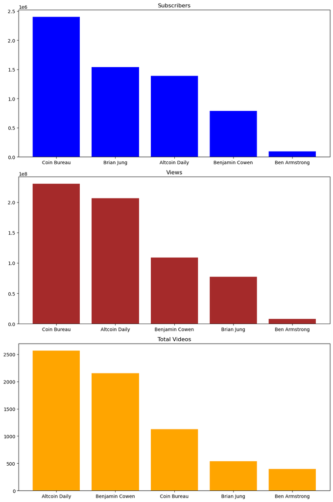

```python
import pandas as pd
import matplotlib.pyplot as plt

# Sort the DataFrame by 'Subscribers' in descending order
combined_crypto_channels_df_subscribers_sorted = combined_crypto_channels_df.sort_values(by='Subscribers', ascending=False)

# Shorten channel names
combined_crypto_channels_df_subscribers_sorted['Channel_name'] = combined_crypto_channels_df_subscribers_sorted['Channel_name'].apply(lambda x: x[:15])

# Plotting Subscribers in descending order
fig, axes = plt.subplots(nrows=3, ncols=1, figsize=(10, 15))

axes[0].bar(combined_crypto_channels_df_subscribers_sorted['Channel_name'], combined_crypto_channels_df_subscribers_sorted['Subscribers'], color='blue')
axes[0].set_title('Subscribers')

# Sort the DataFrame by 'Views' in descending order
combined_crypto_channels_df_views_sorted = combined_crypto_channels_df.sort_values(by='Views', ascending=False)

# Shorten channel names
combined_crypto_channels_df_views_sorted['Channel_name'] = combined_crypto_channels_df_views_sorted['Channel_name'].apply(lambda x: x[:15])

# Plotting Views in descending order
axes[1].bar(combined_crypto_channels_df_views_sorted['Channel_name'],combined_crypto_channels_df_views_sorted['Views'], color='brown')
axes[1].set_title('Views')

# Sort the DataFrame by 'Total_videos' in descending order
combined_crypto_channels_df_total_videos_sorted =combined_crypto_channels_df.sort_values(by='Total_videos', ascending=False)

# Shorten channel names
combined_crypto_channels_df_total_videos_sorted['Channel_name'] = combined_crypto_channels_df_total_videos_sorted['Channel_name'].apply(lambda x: x[:15])

# Plotting Total Videos in descending order
axes[2].bar(combined_crypto_channels_df_total_videos_sorted['Channel_name'], combined_crypto_channels_df_total_videos_sorted['Total_videos'], color='orange')
axes[2].set_title('Total Videos')

# Adjust layout for better visibility
plt.tight_layout()

# Show the plot
plt.show()
```